# churn_data_model_prediction_project

## Data Loading and Basic Information

Import required libraries, read the `Churn.csv` dataset, and display basic info to understand columns, data types, and missing values.

```python
import pandas as pd
import numpy as np
import matplotlib.pyplot as plt
import seaborn as sns
data_path = '/content/Churn.csv'
data = pd.read_csv(data_path)
```

```python
data.info()
```

```
<class 'pandas.core.frame.DataFrame'>
RangeIndex: 7043 entries, 0 to 7042
Data columns (total 21 columns):
 #   Column            Non-Null Count  Dtype
---  ------            --------------  -----
 0   customerID        7043 non-null   object
 1   gender            7043 non-null   object
 2   SeniorCitizen     7043 non-null   int64
 3   Partner           7043 non-null   object
 4   Dependents        7043 non-null   object
 5   tenure            7043 non-null   int64
 6   PhoneService      7043 non-null   object
 7   MultipleLines     7043 non-null   object
 8   InternetService   7043 non-null   object
 9   OnlineSecurity    7043 non-null   object
 10  OnlineBackup      7043 non-null   object
 11  DeviceProtection  7043 non-null   object
 12  TechSupport       7043 non-null   object
 13  StreamingTV       7043 non-null   object
 14  StreamingMovies   7043 non-null   object
 15  Contract          7043 non-null   object
 16  PaperlessBilling  7043 non-null   object
 17  PaymentMethod     7043 non-null   object
 18  MonthlyCharges    7043 non-null   float64
 19  TotalCharges      7043 non-null   object
 20  Churn             7043 non-null   object
dtypes: float64(1), int64(2), object(18)
memory usage: 1.1+ MB
```

## Data Cleaning and Feature Selection

Convert `TotalCharges` to numeric, drop missing values, and select key categorical and numerical features for analysis.

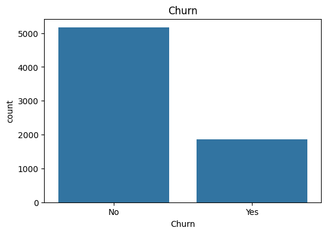

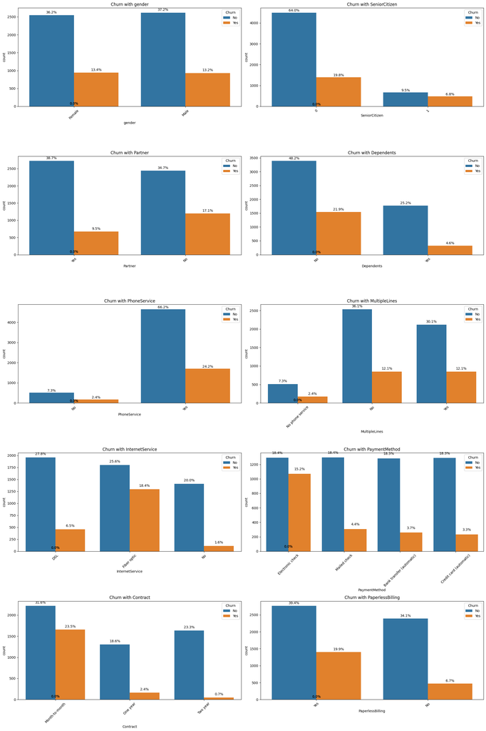

```python
data_v = data.copy()

data_v['TotalCharges'] = pd.to_numeric(data_v['TotalCharges'], errors='coerce')
data_v = data_v.dropna(subset=['TotalCharges'])
feature_1 = ['gender', 'SeniorCitizen' ,'Partner', 'Dependents', 'PhoneService', 'MultipleLines',  'InternetService' ,'PaymentMethod', 'Contract' , 'PaperlessBilling']

plt.figure(figsize=(6, 4))
sns.countplot(data=data_v, x='Churn')
plt.title('Churn')
plt.show()


fig, axes = plt.subplots(5, 2, figsize=(20, 30))
axes = axes.flatten()

for i, feature in enumerate(feature_1):
    sns.countplot(data=data_v, x=feature, hue='Churn', ax=axes[i])
    axes[i].tick_params(axis='x', rotation=45)
    axes[i].legend(title='Churn', loc='upper right')
    axes[i].set_title(f'Churn with {feature}')

    total = len(data_v)
    for p in axes[i].patches:
        height = p.get_height()
        axes[i].text(p.get_x() + p.get_width()/2., height + 50,
                f'{height/total:.1%}', ha='center')

plt.tight_layout()
plt.show()
```

## Visualizing Key Features

Plot distributions of important categorical and numerical features to explore their relationship with customer churn.

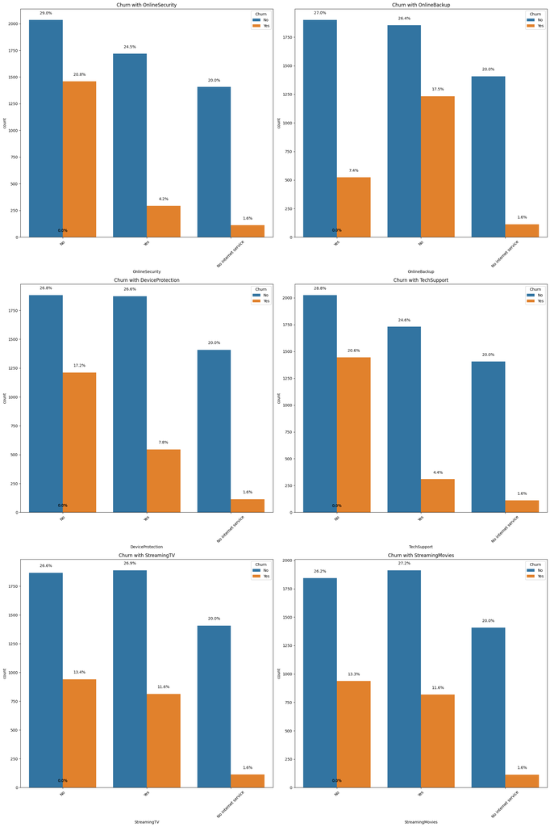

```python
feature_2 = ['OnlineSecurity', 'OnlineBackup' ,'DeviceProtection', 'TechSupport', 'StreamingTV', 'StreamingMovies']

fig, axes = plt.subplots(3, 2, figsize=(20, 30))
axes = axes.flatten()

for i, feature in enumerate(feature_2):
    sns.countplot(data=data_v, x=feature, hue='Churn', ax=axes[i])
    axes[i].tick_params(axis='x', rotation=45)
    axes[i].legend(title='Churn', loc='upper right')
    axes[i].set_title(f'Churn with {feature}')

    total = len(data_v)
    for p in axes[i].patches:
        height = p.get_height()
        axes[i].text(p.get_x() + p.get_width()/2., height + 50,
                f'{height/total:.1%}', ha='center')

plt.tight_layout()
plt.show()
```

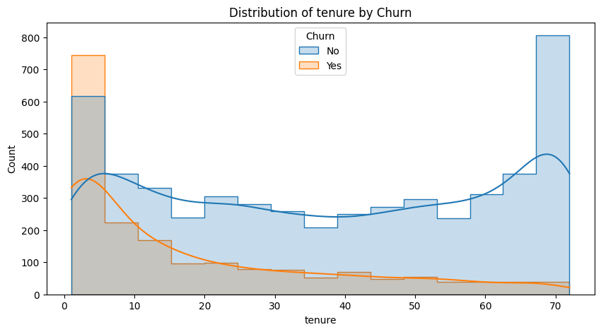

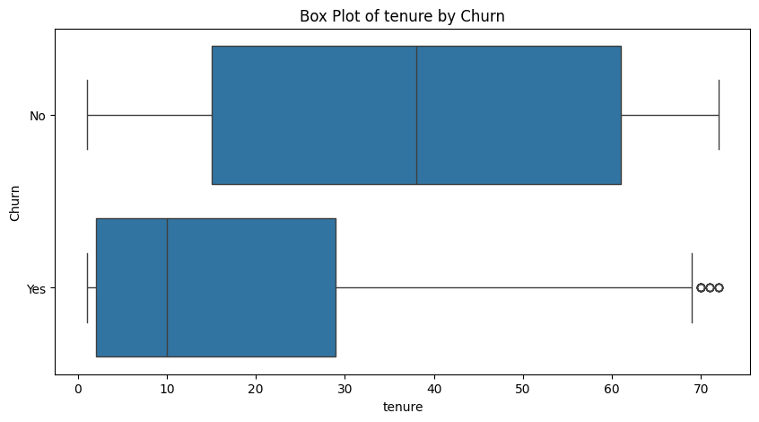

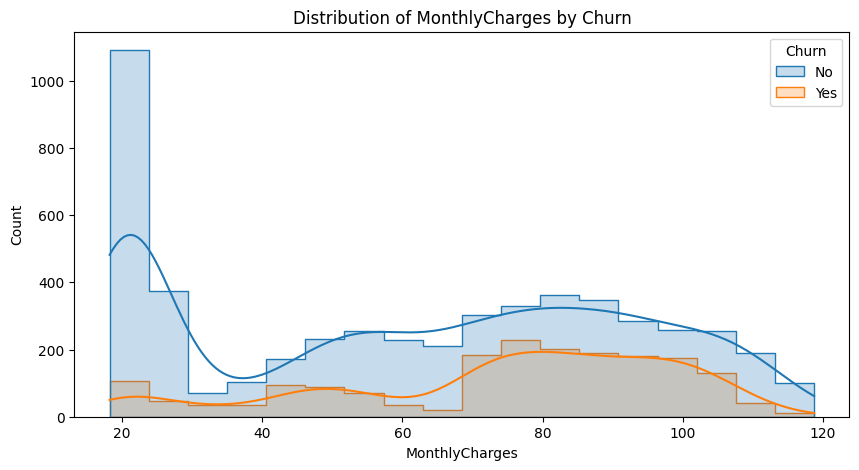

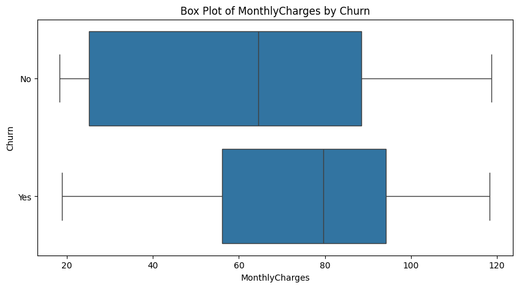

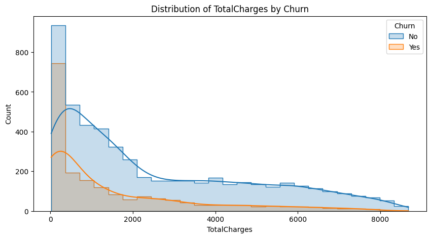

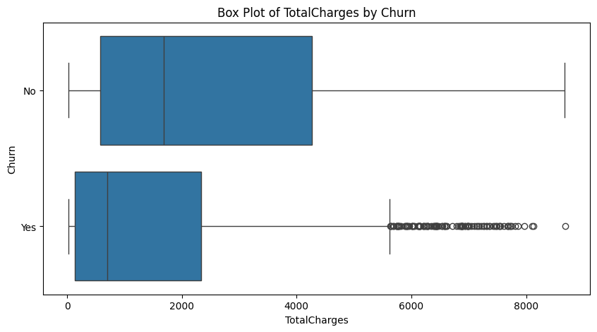

```python
feature_3 = ['tenure', 'MonthlyCharges', 'TotalCharges']
for feature in feature_3:
    plt.figure(figsize=(10, 5))
    sns.histplot(data=data_v, x=feature, hue='Churn', kde=True, element='step')
    plt.title(f'Distribution of {feature} by Churn')
    plt.show()
    plt.figure(figsize=(10, 5))
    sns.boxplot(data=data_v, x=feature, y="Churn")
    plt.title(f'Box Plot of {feature} by Churn')
    plt.show()
```

## Checking for Missing Values

```python
data.info()
```

```
<class 'pandas.core.frame.DataFrame'>
RangeIndex: 7043 entries, 0 to 7042
Data columns (total 21 columns):
 #   Column            Non-Null Count  Dtype
---  ------            --------------  -----
 0   customerID        7043 non-null   object
 1   gender            7043 non-null   object
 2   SeniorCitizen     7043 non-null   int64
 3   Partner           7043 non-null   object
 4   Dependents        7043 non-null   object
 5   tenure            7043 non-null   int64
 6   PhoneService      7043 non-null   object
 7   MultipleLines     7043 non-null   object
 8   InternetService   7043 non-null   object
 9   OnlineSecurity    7043 non-null   object
 10  OnlineBackup      7043 non-null   object
 11  DeviceProtection  7043 non-null   object
 12  TechSupport       7043 non-null   object
 13  StreamingTV       7043 non-null   object
 14  StreamingMovies   7043 non-null   object
 15  Contract          7043 non-null   object
 16  PaperlessBilling  7043 non-null   object
 17  PaymentMethod     7043 non-null   object
 18  MonthlyCharges    7043 non-null   float64
 19  TotalCharges      7043 non-null   object
 20  Churn             7043 non-null   object
dtypes: float64(1), int64(2), object(18)
memory usage: 1.1+ MB
```

```python
data.isna().sum()
```

|  | 0 |
| --- | --- |
| customerID | 0 |
| gender | 0 |
| SeniorCitizen | 0 |
| Partner | 0 |
| Dependents | 0 |
| tenure | 0 |
| PhoneService | 0 |
| MultipleLines | 0 |
| InternetService | 0 |
| OnlineSecurity | 0 |
| OnlineBackup | 0 |
| DeviceProtection | 0 |
| TechSupport | 0 |
| StreamingTV | 0 |
| StreamingMovies | 0 |
| Contract | 0 |
| PaperlessBilling | 0 |
| PaymentMethod | 0 |
| MonthlyCharges | 0 |
| TotalCharges | 0 |
| Churn | 0 |

**dtype:** int64

## Preprocessing Pipeline

Define a preprocessing function to remove unnecessary columns, handle missing values, and prepare data for modeling.

```python
from sklearn.model_selection import train_test_split,GridSearchCV, RandomizedSearchCV
from sklearn.metrics import mean_squared_error, r2_score,classification_report, confusion_matrix,accuracy_score
from sklearn.preprocessing import StandardScaler, LabelEncoder, OneHotEncoder
from sklearn.linear_model import LogisticRegression
from sklearn.tree import DecisionTreeClassifier, plot_tree
from sklearn.svm import SVC
from sklearn.ensemble import RandomForestClassifier
from sklearn.ensemble import AdaBoostClassifier
from sklearn.ensemble import GradientBoostingClassifier
from sklearn.neural_network import MLPClassifier
from scipy.stats import loguniform
from sklearn.neighbors import KNeighborsClassifier


from tensorflow.keras.models import Sequential
from tensorflow.keras.layers import Dense , Dropout, Flatten
from tensorflow.keras.utils import to_categorical
from tensorflow.keras.callbacks import EarlyStopping
from keras.optimizers import SGD
from sklearn.model_selection import RandomizedSearchCV
```

```python
def preprocess_data(data):

    data = data.drop(columns=["customerID", "gender"], axis=1, errors="ignore")
    data["TotalCharges"] = pd.to_numeric(data["TotalCharges"], errors='coerce')
    if data['TotalCharges'].isna().sum()>0:
      print(f"Totalcharge have {data['TotalCharges'].isna().sum()} null value")
    data['TotalCharges'] = data['TotalCharges'].fillna(data['TotalCharges'].median())
    print(f"Totalcharge now have {data['TotalCharges'].isna().sum()} null value")

    encoder = LabelEncoder()
    scaler = StandardScaler()

    num_column=["tenure","MonthlyCharges","TotalCharges"]
    data[num_column] = scaler.fit_transform(data[num_column])

    categorical_column = data.select_dtypes(include=['object']).columns
    for col in categorical_column:
      data[col] = encoder.fit_transform(data[col])

    return data
```

```python
data=preprocess_data(data)
```

```
Totalcharge have 11 null value
Totalcharge now have 0 null value
```

## Splitting Data into Training and Testing Sets

Separate features and target, then split the dataset for model training and evaluation.

```python
x = data.drop("Churn", axis=1)
y = data["Churn"]
x_train, x_test, y_train, y_test = train_test_split(x, y, test_size=0.2, random_state=42)
model_accuracy = {}
```

## Logistic Regression Model

Train and evaluate a Logistic Regression model as a baseline.

```python
logistic_model = LogisticRegression(max_iter=100, random_state=42)
logistic_model.fit(x_train, y_train)
y_logistic_pred = logistic_model.predict(x_test)
model_accuracy['Logistic Regression'] = accuracy_score(y_test, y_logistic_pred)
```

## Support Vector Machine (SVM)

Train and test a linear SVM classifier.

```python
svm_model = SVC(kernel='linear')
svm_model.fit(x_train, y_train)
y_svm_pred = svm_model.predict(x_test)
model_accuracy['svm model'] = accuracy_score(y_test, y_svm_pred)
```

## K-Nearest Neighbors (KNN)

Train and test a KNN classifier with k=7.

```python
knn_model = KNeighborsClassifier(n_neighbors=7)
knn_model.fit(x_train, y_train)
y_knn_pred = knn_model.predict(x_test)
```

## Decision Tree

Build a Decision Tree with entropy criterion and evaluate performance.

```python
dtree_model = DecisionTreeClassifier(max_depth=6,criterion='entropy', random_state=42)
dtree_model.fit(x_train, y_train)
y_dtree_pred = dtree_model.predict(x_test)
model_accuracy['Decision Tree'] = accuracy_score(y_test, y_dtree_pred)
```

## Random Forest

```python
randomforesrt_model = RandomForestClassifier(n_estimators=200,max_depth=10, random_state=42)
randomforesrt_model.fit(x_train, y_train)
y_randomforesrt_pred = randomforesrt_model.predict(x_test)
model_accuracy['random forest'] = accuracy_score(y_test, y_randomforesrt_pred)
```

## Deep Learning Model (MLP)

Train a Multi-layer Perceptron classifier with multiple hidden layers.

```python
Dl_model_1 = MLPClassifier(
    hidden_layer_sizes=(128, 64, 32),
    activation='relu',
    solver='adam',
    max_iter=500,
    random_state=42,
    early_stopping=True,
    n_iter_no_change=10
)
Dl_model_1.fit(x_train, y_train)
y_pred_Dl_1 = Dl_model_1.predict(x_test)
model_accuracy['Dl_model_1 '] = accuracy_score(y_test, y_pred_Dl_1)
```

## Keras Sequential Neural Network

Build and compile a simple Keras neural network for churn prediction.

```python
Sequentialmodel_1 = Sequential([
    Dense(64, activation='relu', input_shape=(x_train.shape[1],)),
    Dense(32, activation='relu'),
    Dense(1, activation='sigmoid' )
])
Sequentialmodel_1.compile(optimizer='SGD', loss='binary_crossentropy', metrics=['accuracy'])
early_stopping = EarlyStopping(monitor='val_loss', patience=5, restore_best_weights=True)
Sequentialmodel_1.fit(x_train, y_train, epochs=50, batch_size=40 ,validation_data=(x_test, y_test),callbacks=[early_stopping])

test_loss, test_accuracy = Sequentialmodel_1.evaluate(x_test, y_test, verbose=0)
print(f"Test Accuracy: {test_accuracy}")

model_accuracy['Sequentialmodel_1 '] = test_accuracy
```

```
141/141 ━━━━━━━━━━━━━━━━━━━━ 1s 5ms/step - accuracy: 0.6942 - loss: 0.5669 - val_accuracy: 0.7594 - val_loss: 0.4751
141/141 ━━━━━━━━━━━━━━━━━━━━ 0s 3ms/step - accuracy: 0.7625 - loss: 0.4805 - val_accuracy: 0.7807 - val_loss: 0.4399
141/141 ━━━━━━━━━━━━━━━━━━━━ 0s 3ms/step - accuracy: 0.7855 - loss: 0.4514 - val_accuracy: 0.7970 - val_loss: 0.4243
141/141 ━━━━━━━━━━━━━━━━━━━━ 1s 5ms/step - accuracy: 0.7863 - loss: 0.4459 - val_accuracy: 0.7963 - val_loss: 0.4171
141/141 ━━━━━━━━━━━━━━━━━━━━ 1s 4ms/step - accuracy: 0.7848 - loss: 0.4334 - val_accuracy: 0.8013 - val_loss: 0.4136
141/141 ━━━━━━━━━━━━━━━━━━━━ 1s 3ms/step - accuracy: 0.7886 - loss: 0.4401 - val_accuracy: 0.8048 - val_loss: 0.4114
141/141 ━━━━━━━━━━━━━━━━━━━━ 0s 3ms/step - accuracy: 0.7983 - loss: 0.4263 - val_accuracy: 0.8112 - val_loss: 0.4097
141/141 ━━━━━━━━━━━━━━━━━━━━ 1s 3ms/step - accuracy: 0.7943 - loss: 0.4234 - val_accuracy: 0.8105 - val_loss: 0.4084
141/141 ━━━━━━━━━━━━━━━━━━━━ 1s 3ms/step - accuracy: 0.8004 - loss: 0.4181 - val_accuracy: 0.8105 - val_loss: 0.4076
141/141 ━━━━━━━━━━━━━━━━━━━━ 0s 3ms/step - accuracy: 0.7947 - loss: 0.4231 - val_accuracy: 0.8133 - val_loss: 0.4065
141/141 ━━━━━━━━━━━━━━━━━━━━ 1s 3ms/step - accuracy: 0.7983 - loss: 0.4204 - val_accuracy: 0.8148 - val_loss: 0.4058
141/141 ━━━━━━━━━━━━━━━━━━━━ 1s 3ms/step - accuracy: 0.7940 - loss: 0.4302 - val_accuracy: 0.8155 - val_loss: 0.4052
141/141 ━━━━━━━━━━━━━━━━━━━━ 0s 3ms/step - accuracy: 0.7944 - loss: 0.4261 - val_accuracy: 0.8155 - val_loss: 0.4048
141/141 ━━━━━━━━━━━━━━━━━━━━ 0s 3ms/step - accuracy: 0.7960 - loss: 0.4207 - val_accuracy: 0.8126 - val_loss: 0.4053
141/141 ━━━━━━━━━━━━━━━━━━━━ 1s 3ms/step - accuracy: 0.8025 - loss: 0.4129 - val_accuracy: 0.8084 - val_loss: 0.4061
141/141 ━━━━━━━━━━━━━━━━━━━━ 1s 3ms/step - accuracy: 0.7961 - loss: 0.4225 - val_accuracy: 0.8112 - val_loss: 0.4048
141/141 ━━━━━━━━━━━━━━━━━━━━ 1s 3ms/step - accuracy: 0.8034 - loss: 0.4200 - val_accuracy: 0.8141 - val_loss: 0.4037
141/141 ━━━━━━━━━━━━━━━━━━━━ 0s 3ms/step - accuracy: 0.8117 - loss: 0.4127 - val_accuracy: 0.8126 - val_loss: 0.4048
141/141 ━━━━━━━━━━━━━━━━━━━━ 1s 3ms/step - accuracy: 0.7951 - loss: 0.4156 - val_accuracy: 0.8141 - val_loss: 0.4037
141/141 ━━━━━━━━━━━━━━━━━━━━ 0s 3ms/step - accuracy: 0.8048 - loss: 0.4047 - val_accuracy: 0.8155 - val_loss: 0.4033
141/141 ━━━━━━━━━━━━━━━━━━━━ 0s 3ms/step - accuracy: 0.7995 - loss: 0.4116 - val_accuracy: 0.8126 - val_loss: 0.4035
141/141 ━━━━━━━━━━━━━━━━━━━━ 1s 3ms/step - accuracy: 0.8056 - loss: 0.4103 - val_accuracy: 0.8162 - val_loss: 0.4037
141/141 ━━━━━━━━━━━━━━━━━━━━ 1s 3ms/step - accuracy: 0.7996 - loss: 0.4233 - val_accuracy: 0.8162 - val_loss: 0.4031
141/141 ━━━━━━━━━━━━━━━━━━━━ 0s 3ms/step - accuracy: 0.8125 - loss: 0.4061 - val_accuracy: 0.8133 - val_loss: 0.4041
141/141 ━━━━━━━━━━━━━━━━━━━━ 1s 4ms/step - accuracy: 0.8002 - loss: 0.4176 - val_accuracy: 0.8155 - val_loss: 0.4033
141/141 ━━━━━━━━━━━━━━━━━━━━ 1s 5ms/step - accuracy: 0.8010 - loss: 0.4180 - val_accuracy: 0.8133 - val_loss: 0.4041
141/141 ━━━━━━━━━━━━━━━━━━━━ 1s 3ms/step - accuracy: 0.8087 - loss: 0.4129 - val_accuracy: 0.8098 - val_loss: 0.4059
141/141 ━━━━━━━━━━━━━━━━━━━━ 1s 3ms/step - accuracy: 0.8023 - loss: 0.4241 - val_accuracy: 0.8183 - val_loss: 0.4034
Test Accuracy: 0.8161816596984863
```

## Model Accuracy Comparison

```python
y_train2 = to_categorical(y_train, num_classes=2)
y_test2 = to_categorical(y_test, num_classes=2)
```

```python
Sequentialmodel_2 = Sequential([
    Dense(256, activation='relu', input_shape=(x_train.shape[1],)),
    Dropout(0.5),
    Dense(128, activation='relu'),
    Dropout(0.5),
    Dense(64, activation='relu'),
    Dropout(0.5),
    Dense(2, activation='softmax')
])
Sequentialmodel_2.compile(optimizer='adam', loss='binary_crossentropy', metrics=['accuracy'])
Sequentialmodel_2.fit(x_train, y_train2, epochs=30, batch_size=20, validation_data=(x_test, y_test2))
test2_loss, test_accuracy2 = Sequentialmodel_2.evaluate(x_test, y_test2, verbose=0)
print(f"Test Accuracy: {test_accuracy2}")
model_accuracy['Sequentialmodel_2 '] = test_accuracy2
```

```
282/282 ━━━━━━━━━━━━━━━━━━━━ 4s 5ms/step - accuracy: 0.7093 - loss: 0.5650 - val_accuracy: 0.8105 - val_loss: 0.4107
282/282 ━━━━━━━━━━━━━━━━━━━━ 1s 4ms/step - accuracy: 0.7798 - loss: 0.4638 - val_accuracy: 0.8112 - val_loss: 0.4124
282/282 ━━━━━━━━━━━━━━━━━━━━ 1s 4ms/step - accuracy: 0.7993 - loss: 0.4363 - val_accuracy: 0.8176 - val_loss: 0.4249
282/282 ━━━━━━━━━━━━━━━━━━━━ 1s 4ms/step - accuracy: 0.7875 - loss: 0.4483 - val_accuracy: 0.8176 - val_loss: 0.4100
282/282 ━━━━━━━━━━━━━━━━━━━━ 1s 3ms/step - accuracy: 0.7929 - loss: 0.4441 - val_accuracy: 0.8006 - val_loss: 0.4104
282/282 ━━━━━━━━━━━━━━━━━━━━ 1s 4ms/step - accuracy: 0.8015 - loss: 0.4336 - val_accuracy: 0.8119 - val_loss: 0.4222
282/282 ━━━━━━━━━━━━━━━━━━━━ 1s 4ms/step - accuracy: 0.7923 - loss: 0.4460 - val_accuracy: 0.8077 - val_loss: 0.4066
282/282 ━━━━━━━━━━━━━━━━━━━━ 1s 4ms/step - accuracy: 0.7960 - loss: 0.4373 - val_accuracy: 0.8112 - val_loss: 0.4059
282/282 ━━━━━━━━━━━━━━━━━━━━ 2s 5ms/step - accuracy: 0.7979 - loss: 0.4337 - val_accuracy: 0.8133 - val_loss: 0.4045
282/282 ━━━━━━━━━━━━━━━━━━━━ 2s 4ms/step - accuracy: 0.7950 - loss: 0.4297 - val_accuracy: 0.8062 - val_loss: 0.4077
282/282 ━━━━━━━━━━━━━━━━━━━━ 1s 3ms/step - accuracy: 0.8002 - loss: 0.4346 - val_accuracy: 0.8070 - val_loss: 0.4067
282/282 ━━━━━━━━━━━━━━━━━━━━ 1s 4ms/step - accuracy: 0.7865 - loss: 0.4415 - val_accuracy: 0.8077 - val_loss: 0.4049
282/282 ━━━━━━━━━━━━━━━━━━━━ 2s 6ms/step - accuracy: 0.8101 - loss: 0.4275 - val_accuracy: 0.8091 - val_loss: 0.4072
282/282 ━━━━━━━━━━━━━━━━━━━━ 2s 6ms/step - accuracy: 0.8006 - loss: 0.4282 - val_accuracy: 0.8020 - val_loss: 0.4121
282/282 ━━━━━━━━━━━━━━━━━━━━ 3s 7ms/step - accuracy: 0.8087 - loss: 0.4172 - val_accuracy: 0.8041 - val_loss: 0.4067
282/282 ━━━━━━━━━━━━━━━━━━━━ 5s 14ms/step - accuracy: 0.8009 - loss: 0.4194 - val_accuracy: 0.8027 - val_loss: 0.4071
282/282 ━━━━━━━━━━━━━━━━━━━━ 3s 7ms/step - accuracy: 0.8073 - loss: 0.4237 - val_accuracy: 0.8062 - val_loss: 0.4093
282/282 ━━━━━━━━━━━━━━━━━━━━ 1s 4ms/step - accuracy: 0.8028 - loss: 0.4222 - val_accuracy: 0.8055 - val_loss: 0.4108
282/282 ━━━━━━━━━━━━━━━━━━━━ 1s 4ms/step - accuracy: 0.8057 - loss: 0.4248 - val_accuracy: 0.8098 - val_loss: 0.4088
282/282 ━━━━━━━━━━━━━━━━━━━━ 1s 4ms/step - accuracy: 0.8053 - loss: 0.4195 - val_accuracy: 0.8091 - val_loss: 0.4234
282/282 ━━━━━━━━━━━━━━━━━━━━ 1s 3ms/step - accuracy: 0.8013 - loss: 0.4292 - val_accuracy: 0.8105 - val_loss: 0.4089
282/282 ━━━━━━━━━━━━━━━━━━━━ 1s 3ms/step - accuracy: 0.7939 - loss: 0.4338 - val_accuracy: 0.8091 - val_loss: 0.4114
282/282 ━━━━━━━━━━━━━━━━━━━━ 2s 5ms/step - accuracy: 0.8054 - loss: 0.4193 - val_accuracy: 0.8141 - val_loss: 0.4066
282/282 ━━━━━━━━━━━━━━━━━━━━ 2s 4ms/step - accuracy: 0.8072 - loss: 0.4229 - val_accuracy: 0.8084 - val_loss: 0.4062
282/282 ━━━━━━━━━━━━━━━━━━━━ 1s 4ms/step - accuracy: 0.7963 - loss: 0.4227 - val_accuracy: 0.8048 - val_loss: 0.4070
282/282 ━━━━━━━━━━━━━━━━━━━━ 1s 3ms/step - accuracy: 0.8129 - loss: 0.4095 - val_accuracy: 0.8062 - val_loss: 0.4112
282/282 ━━━━━━━━━━━━━━━━━━━━ 1s 4ms/step - accuracy: 0.8089 - loss: 0.4200 - val_accuracy: 0.8070 - val_loss: 0.4092
282/282 ━━━━━━━━━━━━━━━━━━━━ 1s 3ms/step - accuracy: 0.8152 - loss: 0.4216 - val_accuracy: 0.8077 - val_loss: 0.4059
282/282 ━━━━━━━━━━━━━━━━━━━━ 1s 5ms/step - accuracy: 0.8078 - loss: 0.4057 - val_accuracy: 0.8084 - val_loss: 0.4088
282/282 ━━━━━━━━━━━━━━━━━━━━ 2s 6ms/step - accuracy: 0.8158 - loss: 0.3995 - val_accuracy: 0.8091 - val_loss: 0.4177
Test Accuracy: 0.8090844750404358
```

```python
print("the accuracy of the logistic regression model is",accuracy_score(y_test, y_logistic_pred))
print("the accuracy of the decision tree model is : ",accuracy_score(y_test,y_dtree_pred))
print("the accuracy of the svm model is : ",accuracy_score(y_test,y_svm_pred))
print("the accuracy of the random forest model is : ",accuracy_score(y_test,y_randomforesrt_pred))
print("the accuracy of the Deep Learning model_1 is : ",accuracy_score(y_test,y_pred_Dl_1))
print("the accuracy of the Sequential model_1 is : ",test_accuracy)
print("the accuracy of the Sequential model_2 is : ",test_accuracy2)
print("the accuracy of the knn model is : ",accuracy_score(y_test,y_knn_pred))
```

```
the accuracy of the logistic regression model is 0.8161816891412349
the accuracy of the decision tree model is :  0.7991483321504613
the accuracy of the svm model is :  0.8190205819730305
the accuracy of the random forest model is :  0.8076650106458482
the accuracy of the Deep Learning model_1 is :  0.8161816891412349
the accuracy of the Sequential model_1 is :  0.8161816596984863
the accuracy of the Sequential model_2 is :  0.8090844750404358
the accuracy of the knn model is :  0.7856635911994322
```

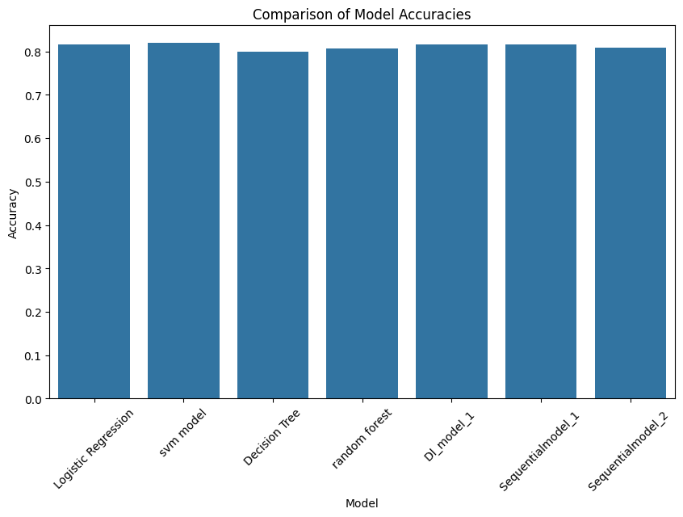

```python
plt.figure(figsize=(10, 6))
sns.barplot(x=list(model_accuracy.keys()), y=list(model_accuracy.values()))
plt.xlabel("Model")
plt.ylabel("Accuracy")
plt.title("Comparison of Model Accuracies")
plt.xticks(rotation=45)
plt.show()
```

```python
param_distributions = {
    'C': loguniform(1e-3, 1e3),
    'kernel': ['linear', 'rbf','sigmoid','poly'],
    'gamma': loguniform(1e-4, 1e1),
    'class_weight': [None, 'balanced']
}

svm_model = SVC()

random_search = RandomizedSearchCV(
    estimator=svm_model,
    param_distributions=param_distributions,
    n_iter=25,
    cv=3,
    scoring='accuracy',
    random_state=42,
)

random_search.fit(x_train, y_train)
print("Best parameters (Randomized Search):", random_search.best_params_)
print("Best score (Randomized Search):", random_search.best_score_)
```

```
Best parameters (Randomized Search): {'C': 4.418441521199722, 'class_weight': None, 'gamma': 0.017885301261862014, 'kernel': 'rbf'}
Best score (Randomized Search): 0.7958821441249556
```